# Exploratory Data Analysis of White Wines by *Eric Perbos-Brinck*

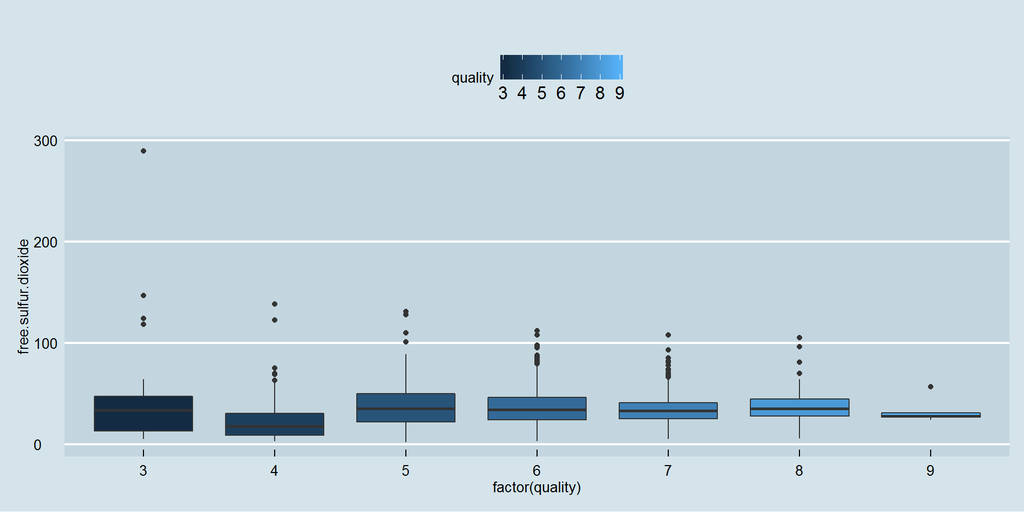

Box plot: *free.sulfur.dioxide* per *quality* grade

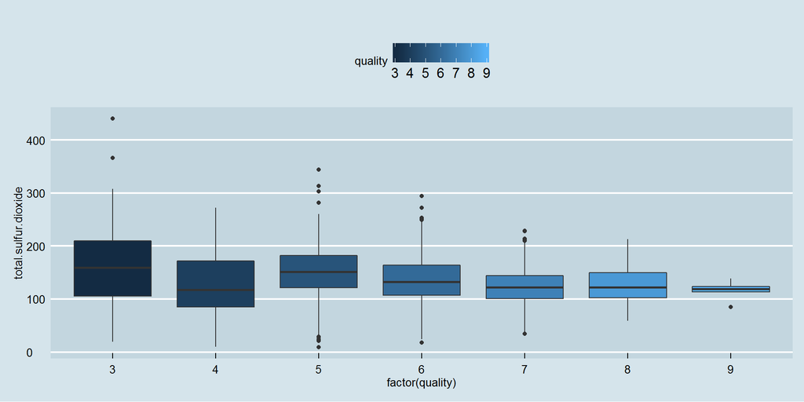

Box plot: *total.sulfur.dioxide* per *quality* grade

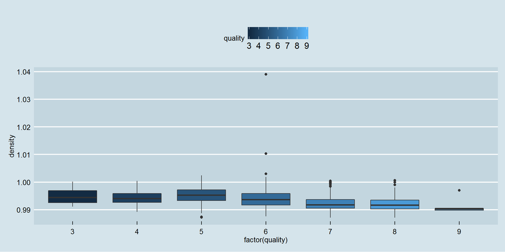

Box plot: *density* per *quality* grade

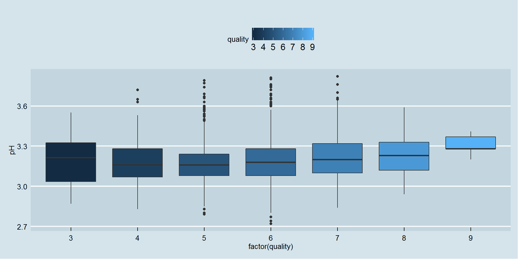

Box plot: *pH* per *quality* grade

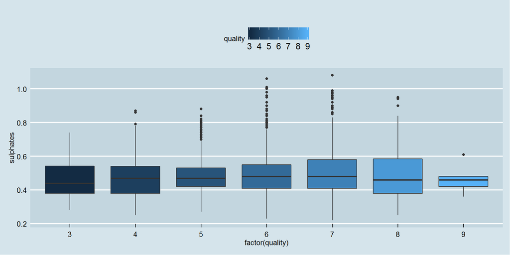

Box plot: *sulphates* per *quality* grade

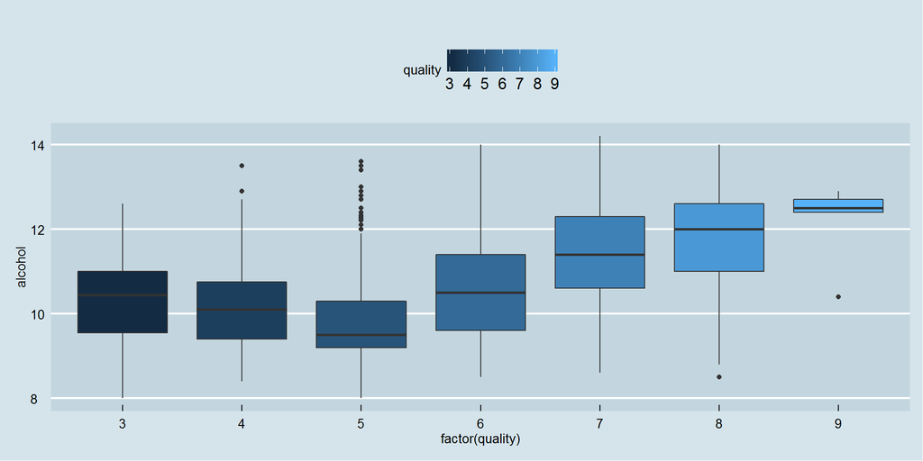

Box plot: *alcohol* per *quality* grade

# Bivariate Analysis

### Did you observe any interesting relationships between the other features (not the main feature(s) of interest)?

The scatter plots visually confirm the correlations, positive and negative, between chemical components as per the pair plots. For example, there is a strong positive correlation between *density* and *residual.sugar* **(+0.84)** while a strong negative one exists between *density* and *alcohol* **(-0.78)**.

### What was the strongest relationship you found?

I found the strongest relationship between *density* and *residual.sugar* with a correlation **(+0.84)**.

# Multivariate Plots Section

We are going to investigate the Top 3 correlations (> |0.5|) in relation with *Quality*.

- density vs residual.sugar +0.84
- density vs alcohol -0.78
- density vs total.sulfur.dioxide +0.53

Also for better ergonomics, we will group the *Quality* grades into 3 categories:

- “Lowest” -> (3, 4)
- “Average” -> (5, 6)
- “Highest” -> (7, 8, 9)

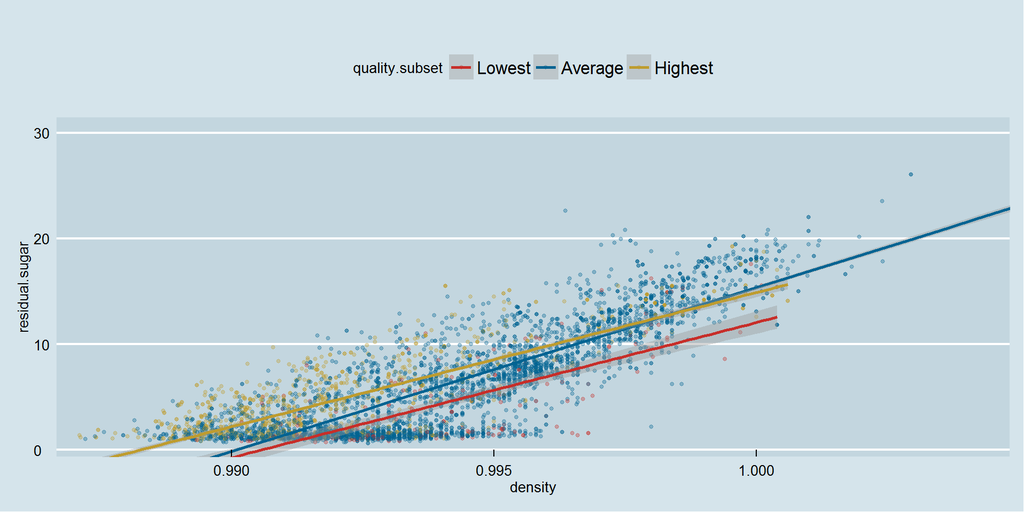

Scatter plot: *residual.sugar* vs *density* by **quality**

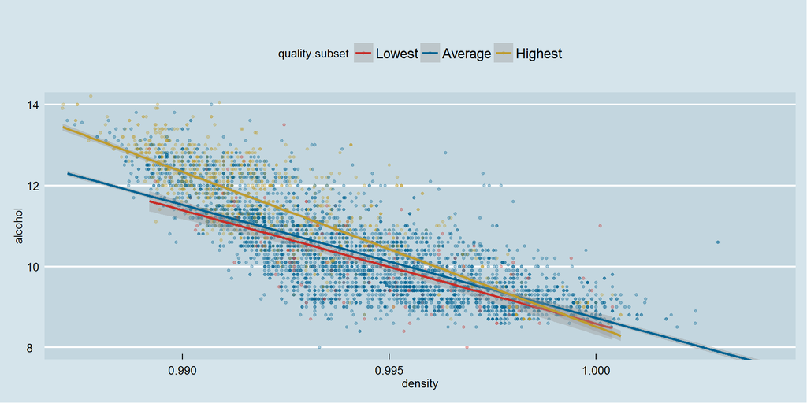

Scatter plot: *density* vs *alcohol* by **quality**

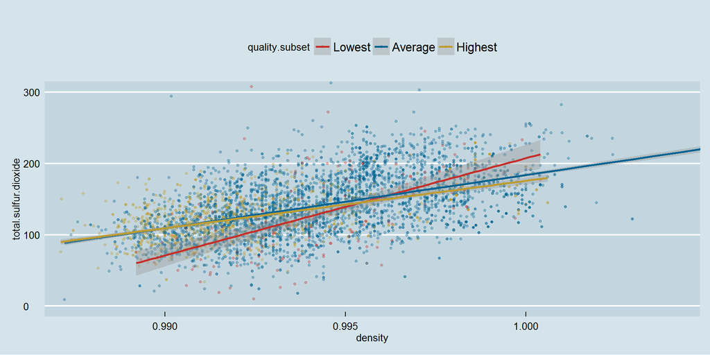

Scatter plot: *density* vs *total.sulfur.dioxide* by **quality**

## Building a linear model

We investigate the creation of a linear model using the Top 5 correlated variables, added in decreasing order of correlation below. (*comments in the Multivariate Analysis*)

```r
m1 <- lm(I(quality) ~ I(alcohol), data = whites)
m2 <- update(m1, ~ . + density)
m3 <- update(m2, ~ . + chlorides)
m4 <- update(m3, ~ . + volatile.acidity)
m5 <- update(m4, ~ . + total.sulfur.dioxide)

mtable(m1, m2, m3, m4, m5)
```

```
##
## Calls:
## m1: lm(formula = I(quality) ~ I(alcohol), data = whites)
## m2: lm(formula = I(quality) ~ I(alcohol) + density, data = whites)
## m3: lm(formula = I(quality) ~ I(alcohol) + density + chlorides, data = whites)
## m4: lm(formula = I(quality) ~ I(alcohol) + density + chlorides +
##     volatile.acidity, data = whites)
## m5: lm(formula = I(quality) ~ I(alcohol) + density + chlorides +
##     volatile.acidity + total.sulfur.dioxide, data = whites)
##
## ===================================================================================
##                            m1          m2          m3          m4          m5
## -----------------------------------------------------------------------------------
##   (Intercept)            2.582***  -22.492***  -21.150***  -35.573***  -30.759***
##                         (0.098)     (6.165)     (6.162)     (6.010)     (6.295)
##   I(alcohol)             0.313***    0.360***    0.343***    0.389***    0.391***
##                         (0.009)     (0.015)     (0.015)     (0.015)     (0.015)
##   density                           24.728***   23.671***   38.217***   33.251***
##                                     (6.079)     (6.074)     (5.926)     (6.234)
##   chlorides                                     -2.382***   -1.300*     -1.370*
##                                                 (0.558)     (0.542)     (0.543)
##   volatile.acidity                                          -2.043***   -2.070***
##                                                             (0.111)     (0.111)
##   total.sulfur.dioxide                                                   0.001*
##                                                                         (0.000)
## -----------------------------------------------------------------------------------
##   R-squared                  0.2        0.2         0.2         0.2         0.2
##   adj. R-squared             0.2        0.2         0.2         0.2         0.2
##   sigma                      0.8        0.8         0.8         0.8         0.8
##   F                       1146.4      583.3       396.3       403.0       324.0
##   p                          0.0        0.0         0.0         0.0         0.0
##   Log-likelihood         -5839.4    -5831.1     -5822.0     -5657.3     -5654.0
##   Deviance                3112.3     3101.8      3090.2      2889.2      2885.4
##   AIC                    11684.8    11670.3     11654.0     11326.6     11322.1
##   BIC                    11704.3    11696.2     11686.5     11365.6     11367.5
##   N                       4898       4898        4898        4898        4898
## ===================================================================================
```

# Multivariate Analysis

### Talk about some of the relationships you observed in this part of the investigation. Were there features that strengthened each other in terms of looking at your feature(s) of interest? Were there any interesting or surprising interactions between features?

The *Quality* subsets, used in scatter plots combined with regression lines, provided a clearer view in two cases:

- *residual.sugar* vs *density* by Quality: Highest quality wines show significantly higher residual values, per same density, than Lower ones. While Average ones sit in between.
- *density* vs *alcohol* by Quality: similar distinction but concentrated on lower density values.

There was no such observation in *density* vs *total.sulfur.dioxide* by quality, as all three regression lines crossed in the central area of the cloud.

### OPTIONAL: Did you create any models with your dataset? Discuss the strengths and limitations of your model.

We created a linear model using the lm() function, gradually including the most correlated variables in descending order (alcohol > density > chlorides …) until completion of m5 model.  
Although it showed some interesting factors as it included more predictors, right from the 1st iteration the R-squared value (adjusted or not) hit a 0.2 value. Thus we felt its potential for prediction was too limited and didn’t convey further investigation with a test set.

# Final Plots and Summary

### Plot One

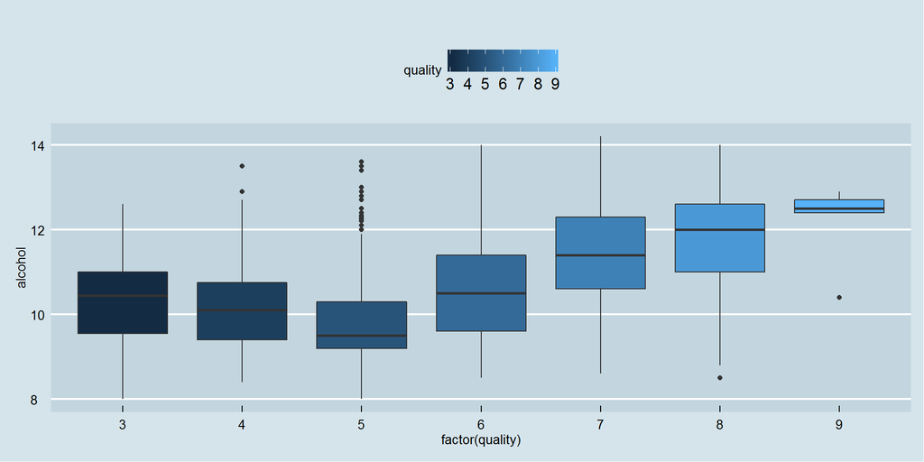

Box plot: *alcohol* per *quality* grade

### Description One

This plot is the most interesting one as it shows a clear relation between alcohol level and the highest grades of wine quality (7,8,9).

### Plot Two

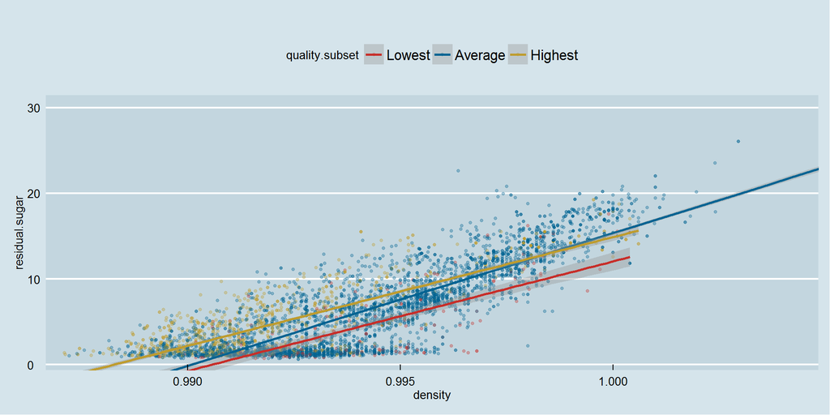

Scatter plot: *residual.sugar* vs *density* by **quality**

### Description Two

This plot positions the three subsets of *Quality* grades with regards to their combined values of *residual.sugar* vs *density* . With the help of regression lines, we can see that Highest Grades tend to have superior *residual.sugar* values for identical *density* than Lowest ones.

### Plot Three

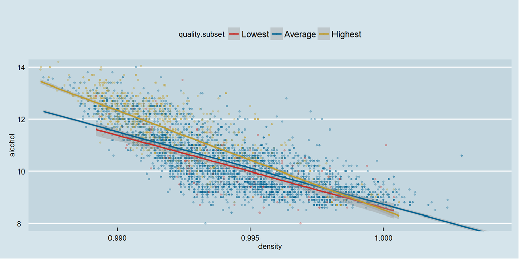

Scatter plot: *density* vs *alcohol* by **quality**

### Description Three

In accordance with our Plot One (box plot *alcohol* vs *quality*), this scatter plot confirms that Highest Grades have distinctively superior *alcohol* levels than Lowest ones at lower density. But contrary to Plot Two, where both regression lines were parallel, the distinction fades away as *density* increases; to the point of merging, including with Average Grades, in the vincinity of 1.000 density and 9.0 alcohol. ——

# Reflection

This dataset is related to white variants of the Portuguese “Vinho Verde” wine. Number of Instances: white wine - 4898 The inputs include objective tests (e.g. PH values) and the output is based on sensory data (median of at least 3 evaluations made by wine experts). Each expert graded the wine quality between 0 (very bad) and 10 (very excellent).

Based on my own -but limited- experience in oenology, I would suggest including other variables for each wine listed such as type of grape, type of soil and meteorology data during growth and harvest.